# 6372 - Project 1

# Reducing Uncertainty in Residential Real Estate

## Estimating Russian Home Prices Through Regression and Variable Selection

Allen Crane

Brock Friedrich

MSDS 6372 Applied Statistics - Modeling and Inference

Dr. Anthony Tanaydin - Fall 2018

2018-10-07

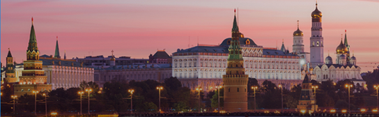

Introduction

For our project, we have been asked to assist the Russian bank Sberbank to predict real estate prices with more certainty, so they can provide more certainty to their customers and value to their shareholders.The goal of this analysis is to build 2 models for the prediction of Russian real estate property. One model will predict the individual property price given some or all of the variables, and another model to predict the mean price of the properties. Both models will use the TRAIN data set to build the model and the PREDICTION data set for the test model.

Objective #1 : Predicting Home Value with Regression

The TRAIN data set was used for this modeling effort. The original file consists of 30,471 observations with 292 variables each. Appendix A contains the complete data dictionary and explanation of variables.

# Data Wrangling

The following variable names exceeded 32 characters, and therefore needed to be trimmed to shorter variable names:

| Before | After |
| --- | --- |
| preschool_education_centers_raion | ps_educ_centers_raion |
| school_education_centers_top_20_raion | s_educ_centers_top20_raion |
| raion_build_count_with_material_info | raion_bld_cnt_material_info |
| public_transport_station_min_walk | pub_trans_stn_min_walk |

Some variables exhibited significant curvature in the QQ plot, so the following variables were created using a log transformation on the original data:

Before

After

area_m

log_area_m = log(area_m)

price_doc

log_price_doc=log(price_doc)

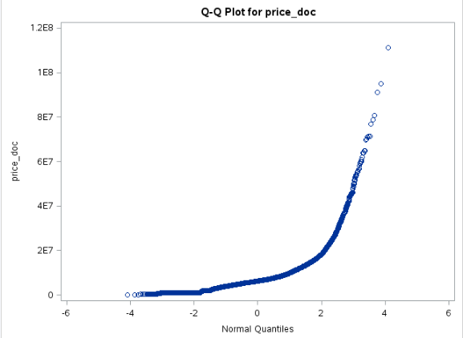

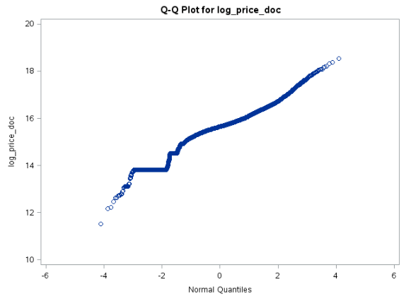

In SAS, variables cannot begin with numeric values. As a result, for those of us coding in SAS, we needed rename the variables to begin with non-numeric values. Using “group_” to proceed the variable names, we have the following:

Before

After

0_6_all

group_0_6_all

0_6_male

group_0_6_male

0_6_female

group_0_6_female

7_14_all

group_7_14_all

7_14_male

group_7_14_male

7_14_female

group_7_14_female

0_17_all

group_0_17_all

0_17_male

group_0_17_male

0_17_female

group_0_17_female

16_29_all

group_16_29_all

16_29_male

group_16_29_male

16_29_female

group_16_29_female

0_13_all

group_0_13_all

0_13_male

group_0_13_male

0_13_female

group_0_13_female

In SAS, variables cannot contain dashes/hyphens (“-”). As a result, for those of us coding in SAS, we needed rename the variables not include dashes/hyphens (“-”). Using an underscore (“_”) to replace (“-”), we have the following:

Before

After

build_count_1921-1945

build_count_1921_1945

'build_count_1946-1970

build_count_1946_1970

'build_count_1971-1995

build_count_1971_1995

Several numeric variables--assumed to be candidates for regression analysis--contained “NA” values. This caused them to be considered by SAS as character variables when the data was loaded into a SAS data set. There is probably a way to do the following in one step, but three steps were used to do this data processing step:

| Before | After |
| --- | --- |
| build_year | n_build_year |
| kitch_sq | n_kitch_sq |
| material | n_material |
| max_floor | n_max_floor |
| num_room | n_num_room |
| state | n_state |

Then we drop the original character variables:

| Before | After |
| --- | --- |
| Drop build_year |  |
| Drop kitch_sq |  |
| Drop material |  |
| Drop max_floor |  |
| Drop num_room |  |
| Drop state |  |

Then we finally rename the “n_*” variables back to the original names:

| Before | After |
| --- | --- |
| Rename | n_build_year build_year |
| Rename | n_kitch_sq kitch_sq |
| Rename | n_ material material |
| Rename | n_max_floor max_floor |
| Rename | n_num_room num_room |
| Rename | n_state state |

# Exploratory Data Analysis

# Outlier Identification and Handling

**Presnensky District>** is an upscale area known for the State Museum of Oriental Art and quiet parks like Patriarch’s Ponds. Child-friendly attractions include the Moscow Zoo, and hands-on exhibits at the nearby Moscow Planetarium. A variety of restaurants serving European and fusion fare line Bolshaya Nikitskaya Street, which is also home to classic repertory at the Mayakovsky Theater.

**Tverskoy District>** is a district of Central Administrative Okrug of the federal city of Moscow, Russia. Population: 75,378; 75,955. The district extends from Kitai-gorod northwest to Belorussky and Savyolovsky Rail Terminals.

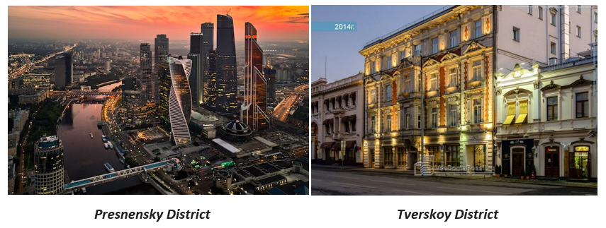

# Missing Data and Imputation

For our analysis, several numeric variables contained non-trivial percentages of missing data (percent of the data with “NA” listed as the value). Since the variable with the highest missing value rate (hospital_beds_raion) is 47%, throwing out the observations with missing values would limit us to just over half of the data set. Similarly, removing the entire variable(s) with missing values could cause us to miss significant coefficients for our predictive models. The following is a list of all variables in the TRAIN data set with missing values, and the missing value percentage of all observations for each variable)

According to Schlomer, Bauman, and Card, “This method is one of several maximum likelihood (ML) approaches. In all ML strategies, observed data are used to estimate parameters, which are then used to estimate the missing scores. These ML strategies have demonstrated superiority to deletion, nonstochastic imputation, and stochastic regression imputation methods (Roth, 1994) for multivariate normal distributions.The EM strategy is based on a recursive process: The missing data have information that is useful in estimating various parameters, and the estimated parameter has information that is useful in finding the most likely value of the missing data (Bennett, 2001). Thus, the EM method is an iterative procedure with two steps in each iteration: In the expectation step, the process is similar to the regression-based imputation. First, starting values for the parameters (e.g., means, covariances) are obtained with available data. Regression methods are used to impute, on the basis of these initial values, the values for the missing data. When this step is completed, in the maximization step new values for the parameters are calculated with the newly imputed data along with the original observed data. Then the process starts over with the expectation step and continues until the estimates change very little from one iteration to the next (i.e., until the estimates converge; Allison, 2001).”

(Source: Gabriel L. Schlomer, Sheri Bauman, and Noel A. Card, “Best Practices for Missing Data Management in Counseling Psychology”, Journal of Counseling Psychology 2010, Vol. 57, No. 1, 1–10)

Below is the generic code for the PROC MI command: (see SAS code in Appendix for detail)

```
              proc mi data=train2 seed=501213
              mu0=0 out=train4;
                   var n_build_year
              …
              n_prom_part_5000;
              run;
```

| Variable | Missing % |
| --- | --- |
| hospital_beds_raion | 47% |
| build_year | 45% |
| state | 44% |
| cafe_sum_500_min_price_avg | 44% |
| cafe_sum_500_max_price_avg | 44% |
| cafe_avg_price_500 | 44% |
| max_floor | 31% |
| material | 31% |
| num_room | 31% |
| kitch_sq | 31% |
| preschool_quota | 22% |
| school_quota | 22% |
| cafe_sum_1000_min_price_avg | 21% |
| cafe_sum_1000_max_price_avg | 21% |
| cafe_avg_price_1000 | 21% |
| life_sq | 21% |
| raion_build_count_with_material_info | 16% |
| build_count_block | 16% |
| build_count_wood | 16% |
| build_count_frame | 16% |
| build_count_brick | 16% |
| build_count_monolith | 16% |
| build_count_panel | 16% |
| build_count_foam | 16% |
| build_count_slag | 16% |
| build_count_mix | 16% |
| raion_build_count_with_builddate_info | 16% |
| build_count_before_1920 | 16% |
| build_count_1921-1945 | 16% |
| build_count_1946-1970 | 16% |
| build_count_1971-1995 | 16% |
| build_count_after_1995 | 16% |
| cafe_sum_2000_min_price_avg | 6% |
| cafe_sum_2000_max_price_avg | 6% |
| cafe_avg_price_2000 | 6% |
| cafe_sum_3000_min_price_avg | 3% |
| cafe_sum_3000_max_price_avg | 3% |
| cafe_avg_price_3000 | 3% |
| cafe_sum_5000_min_price_avg | 1% |
| cafe_sum_5000_max_price_avg | 1% |
| cafe_avg_price_5000 | 1% |
| prom_part_5000 | 1% |
| floor | 1% |

# Missing Data Patterns

In looking at the data, we can see several groups of variables that appear similar. Many of these are in the form of a distance or countable measure between the property (measured in increments of 500, 1000, 1500, 2000, 3000, and 5000 meters) and some item of significance (distance to a cafe with a certain min/max/average price, the number of large churches within an area, distance to leisure areas and markets, etc). An example of one series (“green_part_X”) is shown below:

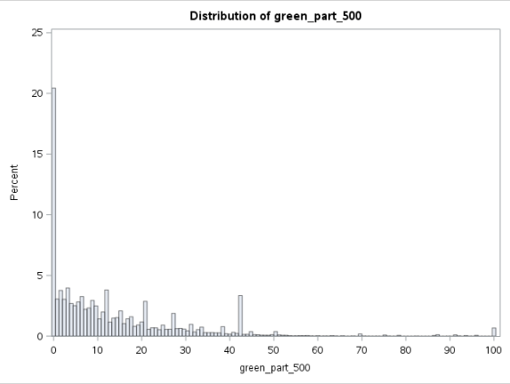

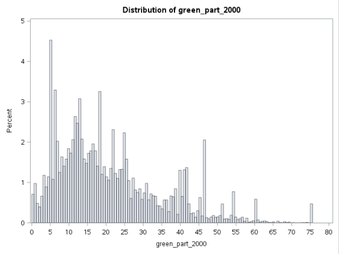

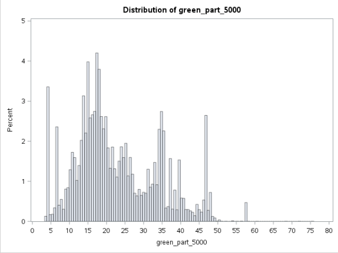

```
proc model data=data;
parms b0 b1;
y = b0 + b1* x;
fit y/white;
Run;
```

# Modeling

1. A model with OLS parameter estimates. You may choose the variables with or without the use of a variable selection technique (forward, backward, stepwise) (You may have done this already in the EDA.)
   - **See Appendix 3: Model 1.1 OLS detail**
2. A model with LASSO estimation and selection.
   - **See Appendix 3: Model 1.2 LASSO detail**
3. A model of your choice. This may be using another OLS or LASSO model or custom model, etc.
   - **See Appendix 3: Model 1.2 LARS detail**

| Model | R2 | AIC | SBC |
| --- | --- | --- | --- |
| OLS (GLM) | 0.4207 |  |  |
| GLMSELECT (AIC) | 0.4207 | 23778403 | 23019085 |
| LASSO | 0.3325 | 23886070 | 23124732 |
| LAR | 0.3325 | 23886070 | 23124732 |

# Prediction

A. Identify which model you feel is the best and discuss why.

Based on the above statistics, we elected to use the reduced GLM SELECT model that optimizes for AIC (/selection=stepwise(select=SL SLE=0.1 SLS=0.08 choose=AIC)). We chose this model because it achieved the highest R2 value, with the fewest number of variables. Hence it was both accurate and more parsimonious that the initial model.

B. Use this model to predict the price of each of the 7662 properties in the prediction data set (predictionData.csv).

See data set named “results_final.csv”. Note: due to PROC MI, we have many thousand more observations than we were asked to produce for the test/prediction data.

C. Submit these predictions in the zip file with your final paper. Please see the sample submission file. SampleSubmission.csv

See data set named “results_final.csv”. Note: due to PROC MI, we have many thousand more observations than we were asked to produce for the test/prediction data.

Source code for Objective #1 can be found in the /src/ folder, titled "Project - 1 *...* .sas"

Objective #2 : Forecasting Mean Home Price using Time Series Analysis

Our analysis will examine the forecasting of mean residential home prices from July 2015 to July 2016, emphasising the identification and remediation of serial effects.

# Data Exploration

Wrangling the dataset to prepare it for analysis was a straitforward effort. Using Python, the data was read into a Pandas dataframe. Once in the dataframe, it was just a matter of applying the timestamp as the dataframe's index, then resampling the dataframe to the desired frequency. In this case, the data is downsampled from it's original frequency of days ('D') to months ('M'), and calculating the mean for each month.

```python
cols = ['timestamp'
        , 'year'
        , 'month'
        , 'day'
        , 'price_doc']
subtrain = train[cols].copy(deep = True)
subtrain = subtrain.set_index('timestamp')
subtrain = subtrain.resample('M').mean()
subtrain = subtrain.sort_index()
subtrain.describe()
```

2015

count

mean

15.37

15.75

std

0.75

0.58

min

12.74

13.12

25%

15.27

15.49

50%

15.52

15.78

75%

15.78

16.07

max

17.43

18.37

<sup>Additional tables in appendix</sup>

```python
train['yearmonth'] = train.timestamp.apply(lambda x: ('{:04d}{:02d}'.format(x.year, x.month)))
```

Vizualizing the timeseries reveals the short-term relationship between price and number of months. The localized positive trend after month 18 is evident. A variety of factors could contribute to explaining the apparent trend, however, full explanation of the relationships between housing features is outside of the scope of this study. We wish only to investigate and quantify potential serial effects that may be present.

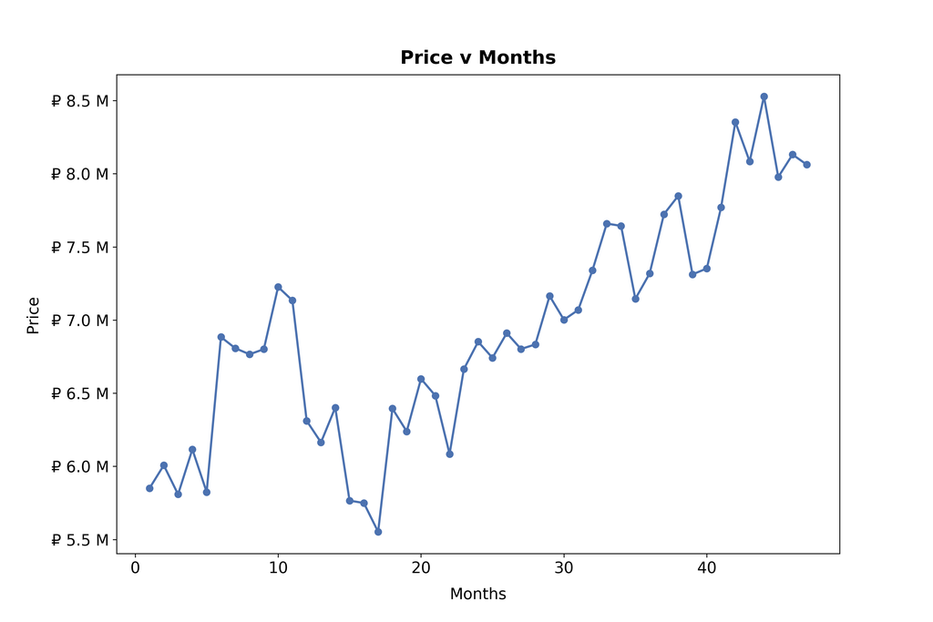

# Assumptions

- Normality
- Homogeneity of Variance
- Mitigation

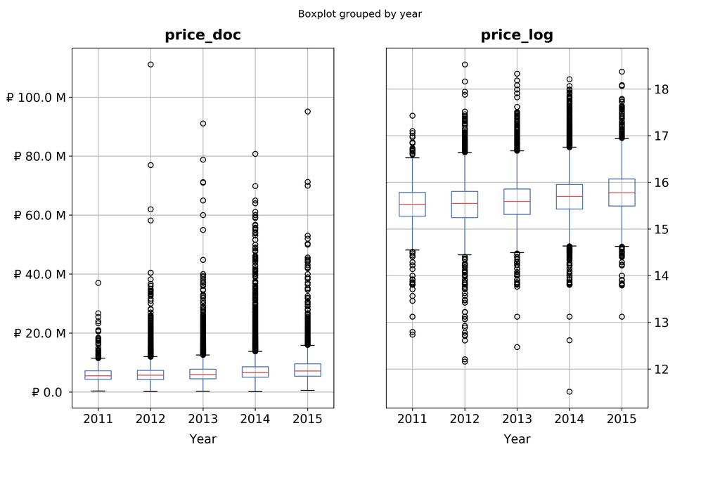

[figure not shown]

- AR Plot

[figure not shown]

# Initial Regression Model

- OLS Model

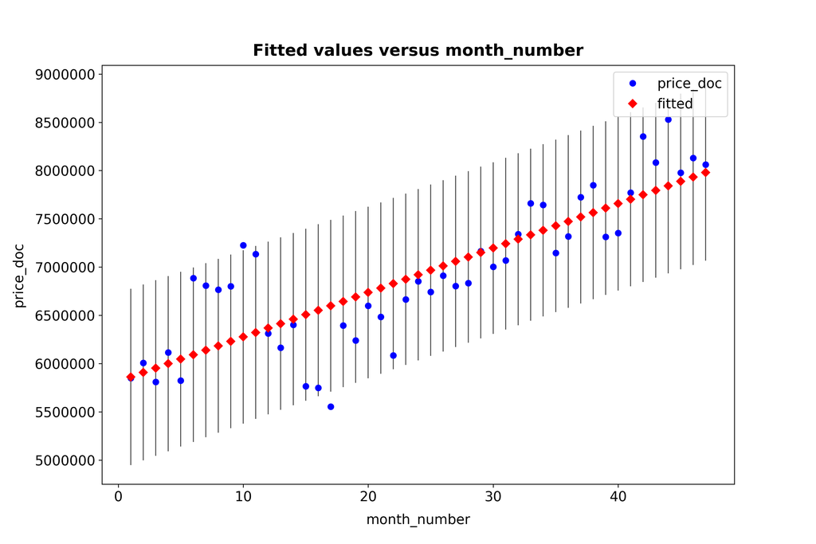

Fit statistics

| Durbin-Watson: | 0.736 | AIC: | 1356 |
| --- | --- | --- | --- |
| Adj. R-squared: | 0.675 | BIC: | 1359 |
| No. Observations: | 47 | Df Model: | 1 |
| F-statistic: | 96.35 | Df Residuals: | 45 |
| P > \|F\| | < 0.001 | R-squared: | 0.682 |

Estimates

Coef.

Estimate

Std.Err.

t

P>|t|

Intercept

5815308

129324

44.97

< 0.001

month_number

46046

4691

9.82

< 0.001

<sup>Additional diagnostics in appendix.</sup>

# Residuals and Partials

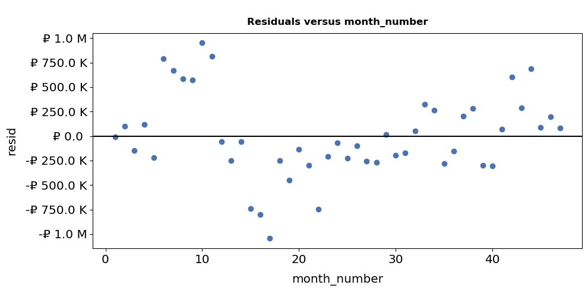

[figure not shown]

# Predicting Mean Home Price

# AR Model Summary

Information Criterion

AIC

25.70

BIC

25.90

Durbin-Watson

1.98

|  | Estimate | t | p > \|t\| | Lower CI | Upper CI | SE |
| --- | --- | --- | --- | --- | --- | --- |
| const | 4014.56 | 0.07 | 0.94 | -101091.43 | 109120.55 | 53626.49 |
| L1.resid | 0.59 | 3.73 | < 0.001 | 0.28 | 0.90 | 0.16 |
| L2.resid | 0.08 | 0.43 | 0.67 | -0.28 | 0.43 | 0.18 |
| L3.resid | -0.00 | -0.02 | 0.98 | -0.31 | 0.31 | 0.16 |

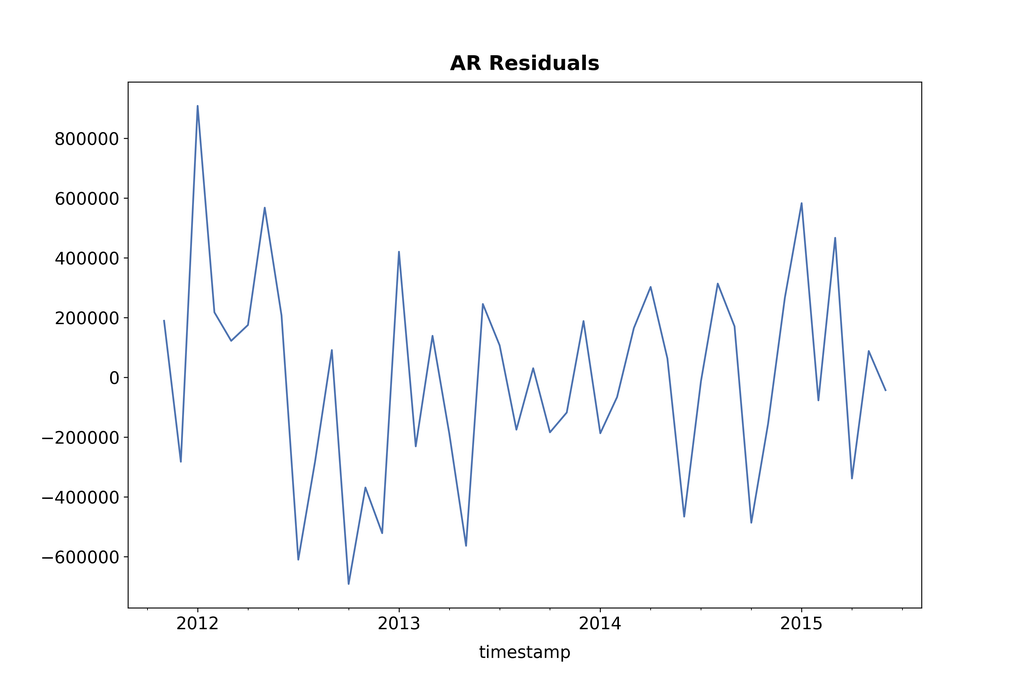

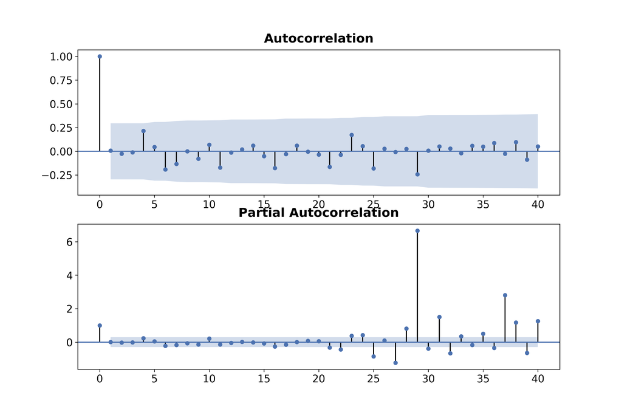

# Predictions

A CSV file of the prediction data can be found in the /docs/ folder under the name p2preds.csv.

| mean | mean_se | mean_ci_lower | mean_ci_upper | obs_ci_lower | obs_ci_upper |
| --- | --- | --- | --- | --- | --- |
| 7979477 | 125261 | 7727187 | 8231767 | 7065329 | 8893624 |
| 8025523 | 129324 | 7765050 | 8285995 | 7109083 | 8941962 |
| 8071569 | 133428 | 7802831 | 8340307 | 7152746 | 8990392 |
| 8117615 | 137569 | 7840536 | 8394695 | 7196318 | 9038912 |
| 8163661 | 141745 | 7878171 | 8449151 | 7239800 | 9087522 |
| 8209707 | 145952 | 7915744 | 8503670 | 7283193 | 9136222 |
| 8255753 | 150188 | 7953259 | 8558248 | 7326497 | 9185010 |
| 8301800 | 154450 | 7990721 | 8612878 | 7369713 | 9233886 |
| 8347846 | 158736 | 8028135 | 8667557 | 7412843 | 9282849 |
| 8393892 | 163044 | 8065503 | 8722281 | 7455886 | 9331897 |
| 8439938 | 167373 | 8102830 | 8777046 | 7498844 | 9381032 |
| 8485984 | 171721 | 8140118 | 8831850 | 7541718 | 9430250 |

Source code for Obective 2 can be found in the problem2.py.

Appendix: Feature Summary

| price_doc | sale price (this is the target variable) |
| --- | --- |
| id | transaction id |
| timestamp | date of transaction |
| full_sq | total area in square meters, including loggias, balconies and other non-residential areas |
| life_sq | living area in square meters, excluding loggias, balconies and other non-residential areas |
| floor | for apartments, floor of the building |
| max_floor | number of floors in the building |
| material | wall material |
| build_year | year built |
| num_room | number of living rooms |
| kitch_sq | kitchen area |
| state | apartment condition |
| product_type | owner-occupier purchase or investment |
| sub_area | name of the district |

The dataset also includes a collection of features about each property’s surrounding neighbourhood, and some features that are constant across each sub area (known as a Raion). Most of the feature names are self explanatory, with the following notes. See below for a complete list.

| full_all | subarea population |
| --- | --- |
| male_f, female_f | subarea population by gender |
| young_* | population younger than working age |
| work_* | working-age population |
| ekder_* | retirement-age population |
| n_m_{all | male |
| build_count_* | buildings in the subarea by construction type or year |
| x_count_500 | the number of x within 500m of the property |
| x_part_500 | the share of x within 500m of the property |
| *sqm* | square meters |
| cafe_count_d_price_p | number of cafes within d meters of the property that have an average bill under p RUB |
| trc_ | shopping malls |
| prom_ | industrial zones |
| green_ | green zones |
| metro_ | subway |
| *avto* | distances by car |
| mkad_ | Moscow Circle Auto Road |
| ttk_ | Third Transport Ring |
| sadovoe_ | Garden Ring |
| bulvar_ring_ | Boulevard Ring |
| kremlin_ | City center |
| zd_vokzaly_ | Train station |
| oil_chemistry_ | Dirty industry |
| ts_ | Power plant |

# Complete description of neighbourhood features

| Feature | Description |
| --- | --- |
| area_m | Area mun. area, sq.m. |
| raion_popul | Number of municipality population. district |
| green_zone_part | Proportion of area of greenery in the total area |
| indust_part | Share of industrial zones in area of the total area |
| children_preschool | Number of pre-school age population |
| preschool_quota | Number of seats in pre-school organizations |
| preschool_education_centers_raion | Number of pre-school institutions |
| children_school | Population of school-age children |
| school_quota | Number of high school seats in area |
| school_education_centers_raion | Number of high school institutions |
| school_education_centers_top_20_raion | Number of high schools of the top 20 best schools in Moscow |
| hospital_beds_raion | Number of hospital beds for the district |
| healthcare_centers_raion | Number of healthcare centers in district |
| university_top_20_raion | Number of higher education institutions in the top ten ranking of the Federal rank |
| sport_objects_raion | Number of higher education institutions |
| additional_education_raion | Number of additional education organizations |
| culture_objects_top_25 | Presence of the key objects of cultural heritage (significant objects for the level of the RF constituent entities, city) |
| culture_objects_top_25_raion | Number of objects of cultural heritage |
| shopping_centers_raion | Number of malls and shopping centres in district |
| office_raion | Number of malls and shopping centres in district |
| thermal_power_plant_raion | Presence of thermal power station in district |
| incineration_raion | Presence of incinerators |
| oil_chemistry_raion | Presence of dirty industries |
| radiation_raion | Presence of radioactive waste disposal |
| railroad_terminal_raion | Presence of the railroad terminal in district |
| big_market_raion | Presence of large grocery / wholesale markets |
| nuclear_reactor_raion | Presence of existing nuclear reactors |
| detention_facility_raion | Presence of detention centers, prisons |
| full_all | Total number of population in the municipality |
| male_f | Male population |

[output cut: 258 more lines]

- train.csv and test.csv
- Complete description of neighbourhood features

Appendix: Feature Summary

# Feature Summary

|  | count | mean | std | min | 25% | 50% | 75% | max |
| --- | --- | --- | --- | --- | --- | --- | --- | --- |
| id | 30471.00 | 15237.92 | 8796.50 | 1.00 | 7620.50 | 15238.00 | 22855.50 | 30473.00 |
| full_sq | 30471.00 | 54.21 | 38.03 | 0.00 | 38.00 | 49.00 | 63.00 | 5326.00 |
| life_sq | 24088.00 | 34.40 | 52.29 | 0.00 | 20.00 | 30.00 | 43.00 | 7478.00 |
| floor | 30304.00 | 7.67 | 5.32 | 0.00 | 3.00 | 6.50 | 11.00 | 77.00 |
| max_floor | 20899.00 | 12.56 | 6.76 | 0.00 | 9.00 | 12.00 | 17.00 | 117.00 |
| material | 20899.00 | 1.83 | 1.48 | 1.00 | 1.00 | 1.00 | 2.00 | 6.00 |
| build_year | 16866.00 | 3068.06 | 154387.80 | 0.00 | 1967.00 | 1979.00 | 2005.00 | 20052009.00 |
| num_room | 20899.00 | 1.91 | 0.85 | 0.00 | 1.00 | 2.00 | 2.00 | 19.00 |
| kitch_sq | 20899.00 | 6.40 | 28.27 | 0.00 | 1.00 | 6.00 | 9.00 | 2014.00 |
| state | 16912.00 | 2.11 | 0.88 | 1.00 | 1.00 | 2.00 | 3.00 | 33.00 |
| area_m | 30471.00 | 17657051.42 | 20649607.99 | 2081627.76 | 7307410.57 | 10508030.10 | 18036436.51 | 206071809.20 |
| raion_popul | 30471.00 | 84056.43 | 57871.29 | 2546.00 | 21819.00 | 83502.00 | 122862.00 | 247469.00 |
| green_zone_part | 30471.00 | 0.22 | 0.18 | 0.00 | 0.06 | 0.17 | 0.34 | 0.85 |
| indust_part | 30471.00 | 0.12 | 0.12 | 0.00 | 0.02 | 0.07 | 0.20 | 0.52 |
| children_preschool | 30471.00 | 5140.03 | 3816.63 | 175.00 | 1706.00 | 4857.00 | 7103.00 | 19223.00 |
| preschool_quota | 23783.00 | 3271.27 | 2169.76 | 0.00 | 1874.00 | 2854.00 | 4050.00 | 11926.00 |
| preschool_education_centers_raion | 30471.00 | 4.07 | 2.99 | 0.00 | 2.00 | 4.00 | 6.00 | 13.00 |
| children_school | 30471.00 | 5354.27 | 3989.64 | 168.00 | 1564.00 | 5261.00 | 7227.00 | 19083.00 |
| school_quota | 23786.00 | 8324.97 | 4289.73 | 1012.00 | 5782.00 | 7377.00 | 9891.00 | 24750.00 |
| school_education_centers_raion | 30471.00 | 4.71 | 3.45 | 0.00 | 2.00 | 5.00 | 7.00 | 14.00 |
| school_education_centers_top_20_raion | 30471.00 | 0.11 | 0.33 | 0.00 | 0.00 | 0.00 | 0.00 | 2.00 |
| hospital_beds_raion | 16030.00 | 1190.74 | 1057.02 | 0.00 | 520.00 | 990.00 | 1786.00 | 4849.00 |
| healthcare_centers_raion | 30471.00 | 1.32 | 1.49 | 0.00 | 0.00 | 1.00 | 2.00 | 6.00 |
| university_top_20_raion | 30471.00 | 0.14 | 0.44 | 0.00 | 0.00 | 0.00 | 0.00 | 3.00 |
| sport_objects_raion | 30471.00 | 6.64 | 6.57 | 0.00 | 1.00 | 5.00 | 10.00 | 29.00 |
| additional_education_raion | 30471.00 | 2.90 | 3.29 | 0.00 | 1.00 | 2.00 | 4.00 | 16.00 |
| culture_objects_top_25_raion | 30471.00 | 0.29 | 1.51 | 0.00 | 0.00 | 0.00 | 0.00 | 10.00 |
| shopping_centers_raion | 30471.00 | 4.20 | 4.74 | 0.00 | 1.00 | 3.00 | 6.00 | 23.00 |
| office_raion | 30471.00 | 8.25 | 23.54 | 0.00 | 0.00 | 2.00 | 5.00 | 141.00 |
| full_all | 30471.00 | 146306.15 | 283025.12 | 2546.00 | 28179.00 | 85219.00 | 125111.00 | 1716730.00 |

[output cut: 249 more lines]

:)